# Lab 4B - Clustering (Hard)

### 1. Explore the Data

1. Set the working directory to “C:/Workshop/Data”

```r
setwd("C:/Workshop/Data")
```

2. Load the Rates.csv data into a dataframe called “policies”

```r
policies <- read.csv("Rates.csv")
```

3. Load the dplyr package

```r
library(dplyr)
```

4. Convert all policies data into numeric values with the following code.

```r
policiesNumeric <- policies %>%
  mutate(Gender = as.numeric(Gender)) %>%
  select(-State)
```

5. Inspect the results

```r
head(policiesNumeric)
```

```
##   Gender State.Rate Height Weight      BMI Age       Rate
## 1      2 0.10043368    184   67.8 20.02599  77 0.33200000
## 2      2 0.14172319    163   89.4 33.64824  82 0.86914779
## 3      2 0.09080315    170   81.2 28.09689  31 0.01000000
## 4      2 0.11997276    175   99.7 32.55510  39 0.02153204
## 5      2 0.11034460    184   72.1 21.29608  68 0.14975000
## 6      2 0.16292470    166   98.4 35.70910  64 0.21123703
```

6. Question: Why do you think we are converting all policy data to numeric values before using our clustering algorithms?

### 2. Create Equal Size Clusters using a Single Variable

1. Load the RColorBrewer package

```r
library(RColorBrewer)
```

2. Create a “Set2” color palette with 3 colors

```r
palette <- brewer.pal(3, "Set2")
```

3. Cut the policies mortality rates into 3 equaldistant clusters

```r
cuts <- cut(policiesNumeric$Rate, 3)
```

4. Create a scatterplot matrix colored by mortality rate clusters.

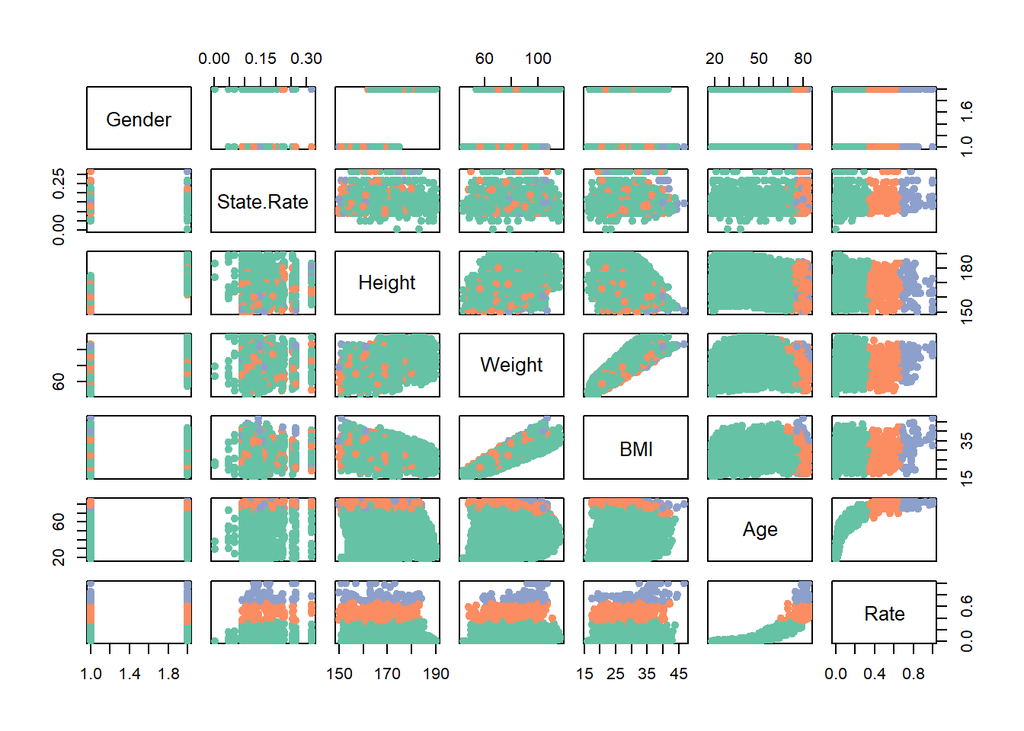

```r
plot(
  x = policiesNumeric,
  col = palette[cuts],
  pch = 19)
```

5. Question: How might these three market segments (based on Mortality Rates) be useful?

### 3. Create Clusters using k-Means

1. Set the seed to 42 to make randomness reproducable.

```r
set.seed(42)
```

2. Create K-means clusters.

```r
kClusters <- kmeans(
  x = policiesNumeric,
  centers = 3,
  nstart = 10)
```

3. Create a scatterplot matrix colored by cluster.

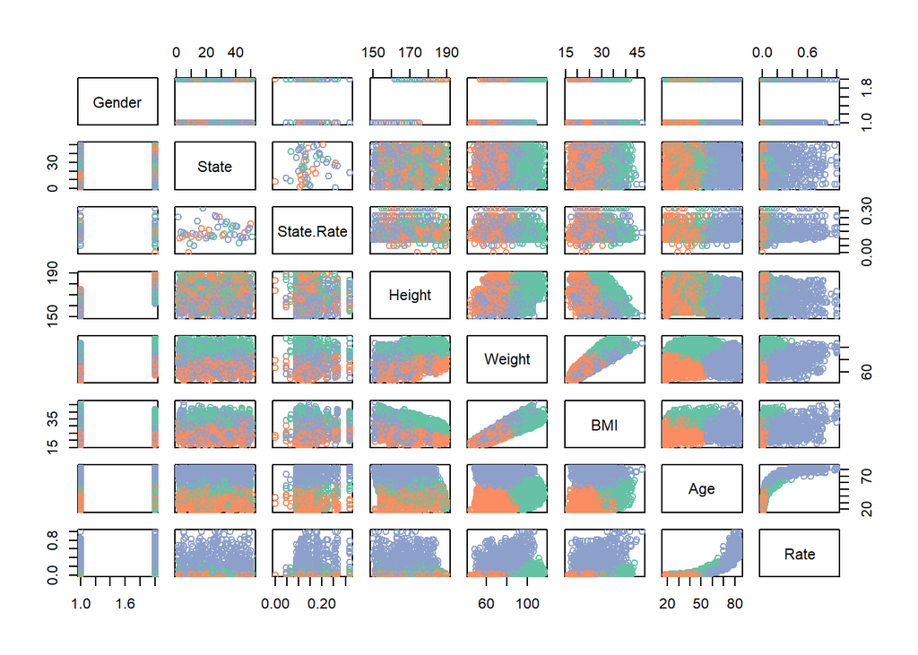

```r
plot(
  x = policies,
  col = palette[kClusters$cluster])
```

4. Create a scatterplot of BMI vs Age colored by cluster.

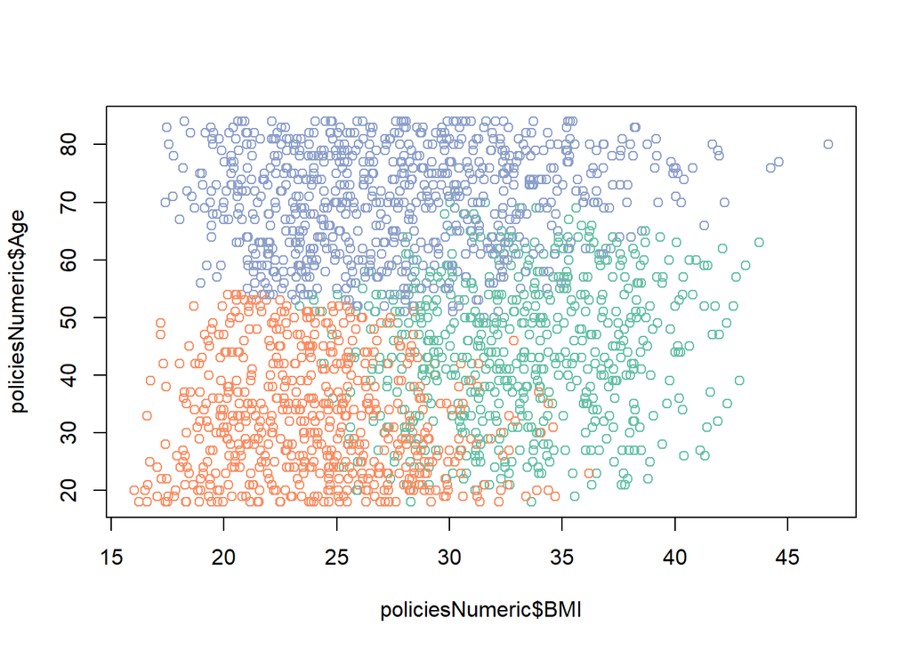

```r
plot(
  x = policiesNumeric$BMI,
  y = policiesNumeric$Age,
  col = palette[kClusters$cluster])
```

5. Plot the centroids of the clusters.

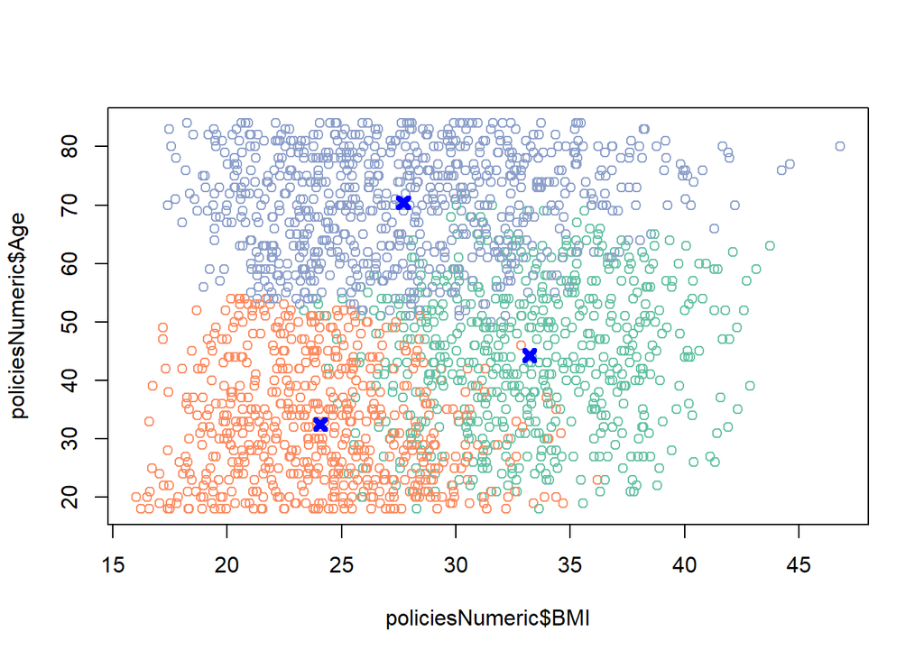

```r
plot(
  x = policiesNumeric$BMI,
  y = policiesNumeric$Age,
  col = palette[kClusters$cluster])

points(
  x = kClusters$centers[, "BMI"],
  y = kClusters$centers[, "Age"],
  pch = 4,
  lwd = 4,
  col = "blue")
```

6. Plot the labels of the clusters.

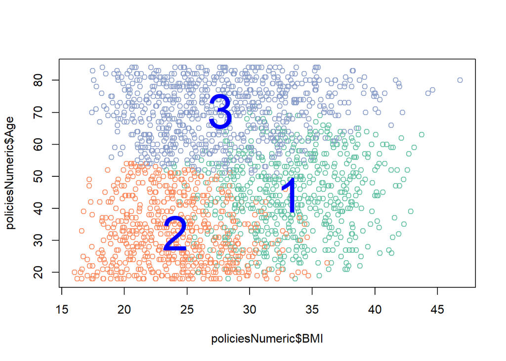

```r
plot(
  x = policiesNumeric$BMI,
  y = policiesNumeric$Age,
  col = palette[kClusters$cluster])

text(
  x = kClusters$centers[, "BMI"],
  y = kClusters$centers[, "Age"],
  labels = c(1, 2, 3),
  cex = 4,
  lwd = 4,
  col = "blue")
```

7. Question: What would you name each of these three clusters?
8. Question: How might these market segments be more or less useful than the previous three segments?

### 4. Create Hierachical Clusters

1. Create hierachical clusters.

```r
hclusters <- hclust(dist(policiesNumeric))
```

2. Cut tree into 3 clusters.

```r
hCuts <- cutree(
  tree = hclusters,
  k = 3)
```

3. Create a scatterplot matrix colored by cluster.

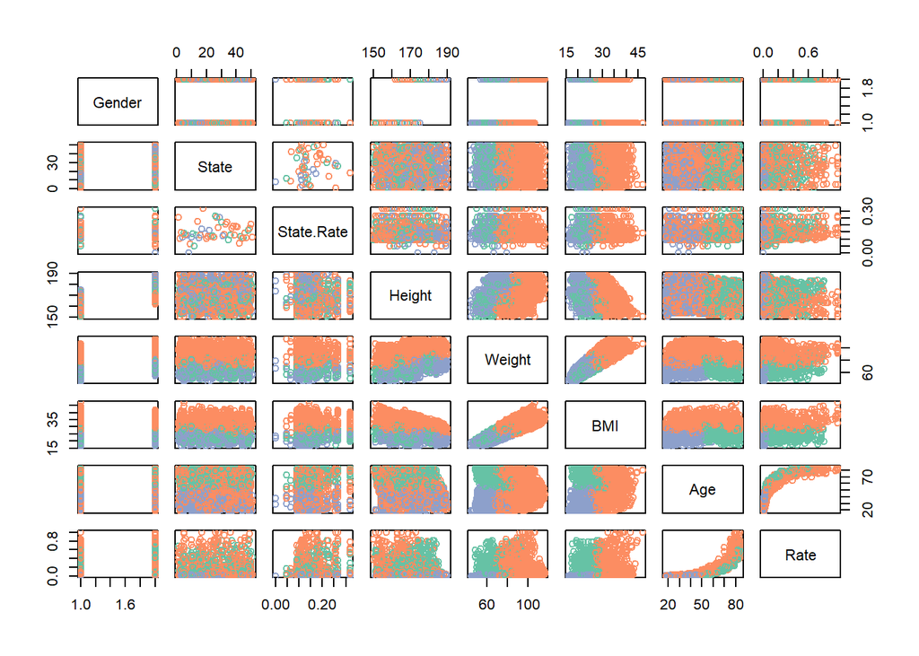

```r
plot(
  x = policies,
  col = palette[hCuts])
```

4. Create a scatterplot of BMI and Age and color by cluster.

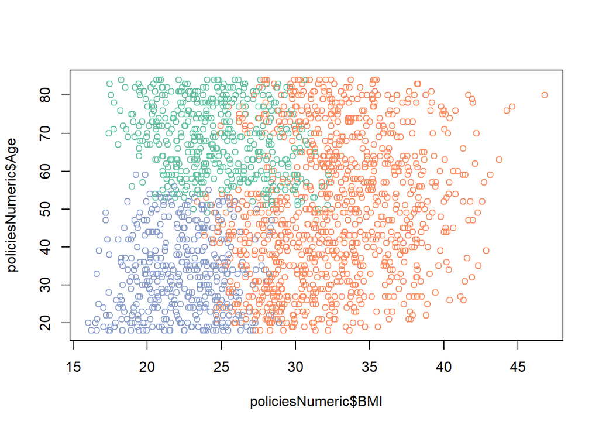

```r
plot(
  x = policiesNumeric$BMI,
  y = policiesNumeric$Age,
  col = palette[hCuts])
```

5. Question: What would you name each of these three market segments?
6. Question: How might these market segments be more or less useful than the previous clusters?